# What Kind Of Soccer Players Should I Buy?

Yexin Wu

5/17/2018

## European Soccer Player Analysis (What kind of soccer players should I buy)

## Introduction:

Modern soccer is totally different from the past. Nowdays, moderen scorrer not only need huge fundings but also professional analysis. Many soccer club such as [AC MILAN](http://www.dailymail.co.uk/sport/football/article-4843522/AC-Milan-confirm-summer-spending-total-210m.html) they spent more than 200 millon dollars. But Eventually they just ranked 6th in Italy’s SeriesA. Soccer club  
manager takes more and more important role in the Club. He should know how to use limited fundings to buy the soccer player they need. He should balance the budget to satisfy [FFP](https://en.wikipedia.org/wiki/UEFA_Financial_Fair_Play_Regulations).

Thus, the purpose of this project is to analyze which soccer player I should buy if I were a soccer manager of the club.

## Required Tools

R markdown, library DBI,dplyr and so on. You can see them in the setup chunk.

## Non-GoalKeeper Player Analysis

## 1. Get Start

First, download the dataset from [Kaggle](https://www.kaggle.com/hugomathien/soccer/kernels?sortBy=hotness&group=everyone&pageSize=20&datasetId=63&language=R). This will be in the form of a sql called database.sql. Now, we will need to load our sql file into a form that we can manipulate using R. To do this, we will use the RSQLite library.

```r
con <- dbConnect(SQLite(), dbname="~/Desktop/cmsc320final/database.sqlite")
players <- tbl_df(dbGetQuery(con,"SELECT * FROM player"))
player_attributes <- tbl_df(dbGetQuery(con,"SELECT * FROM player_attributes"))

## clear data
player_attributes$attacking_work_rate[player_attributes$attacking_work_rate == "le" |
                            player_attributes$attacking_work_rate == "stoc" |
                            player_attributes$attacking_work_rate == "y" |
                            player_attributes$attacking_work_rate == "None"] <- NA

## players contain information about plyers basic information such as
## birthday, age and so on. Players_attributes contain information about
## the players' over_all ratings information each match
players <- players %>%
      inner_join(player_attributes, by = "player_api_id") %>%
      select(-id.y, -player_fifa_api_id.y) %>%
      filter(gk_diving<30) %>%   ## we are considering Non-goalKeeper Player
      select(-starts_with("gk_")) %>%
      mutate(year = as.factor(format(as.Date(date),'%Y'))) %>%    ## change the format of year data
      mutate(date = as.Date(date)) %>%
      mutate(birthday = as.Date(birthday)) %>%
      mutate(age = floor(as.numeric(date-birthday)/365))    ## calculate the age when player play the game

players
```

```
## # A tibble: 168,147 x 43
##     id.x player_api_id player_name     player_fifa_api_… birthday   height
##    <int>         <int> <chr>                       <int> <date>      <dbl>
##  1     1        505942 Aaron Appindan…            218353 1992-02-29    183
##  2     1        505942 Aaron Appindan…            218353 1992-02-29    183
##  3     1        505942 Aaron Appindan…            218353 1992-02-29    183
##  4     1        505942 Aaron Appindan…            218353 1992-02-29    183
##  5     1        505942 Aaron Appindan…            218353 1992-02-29    183
##  6     2        155782 Aaron Cresswell            189615 1989-12-15    170
##  7     2        155782 Aaron Cresswell            189615 1989-12-15    170
##  8     2        155782 Aaron Cresswell            189615 1989-12-15    170
##  9     2        155782 Aaron Cresswell            189615 1989-12-15    170
## 10     2        155782 Aaron Cresswell            189615 1989-12-15    170
## # ... with 168,137 more rows, and 37 more variables: weight <int>,
## #   date <date>, overall_rating <int>, potential <int>,
## #   preferred_foot <chr>, attacking_work_rate <chr>,
## #   defensive_work_rate <chr>, crossing <int>, finishing <int>,
## #   heading_accuracy <int>, short_passing <int>, volleys <int>,
## #   dribbling <int>, curve <int>, free_kick_accuracy <int>,
## #   long_passing <int>, ball_control <int>, acceleration <int>,
## #   sprint_speed <int>, agility <int>, reactions <int>, balance <int>,
## #   shot_power <int>, jumping <int>, stamina <int>, strength <int>,
## #   long_shots <int>, aggression <int>, interceptions <int>,
## #   positioning <int>, vision <int>, penalties <int>, marking <int>,
## #   standing_tackle <int>, sliding_tackle <int>, year <fct>, age <dbl>
```

## Part(1) Age’s influence.

A big problem which Soccer managers are always faced is Should I buy the the old players? Usually, old players always have a lot of experience, can teach young players. However, their performance may be not so good due to health reason. Therefore, I draw the distrbution of Overall_rating conditioned on the age to reveal some information.

Conclusion: (1) Firstly, I use violin-grpah to show the distribution of overall_rating conditioned on age. From the graph, the variance of distribution decreaes acroos years. And we can see the mean doesn’t change a lot. You can not expect too much of those old players, they cannot bring too much surprise. But their performance is much more stable than young players’.

2. Secondly, I draw the linear regression line, which will make the above conclusion more obvious.

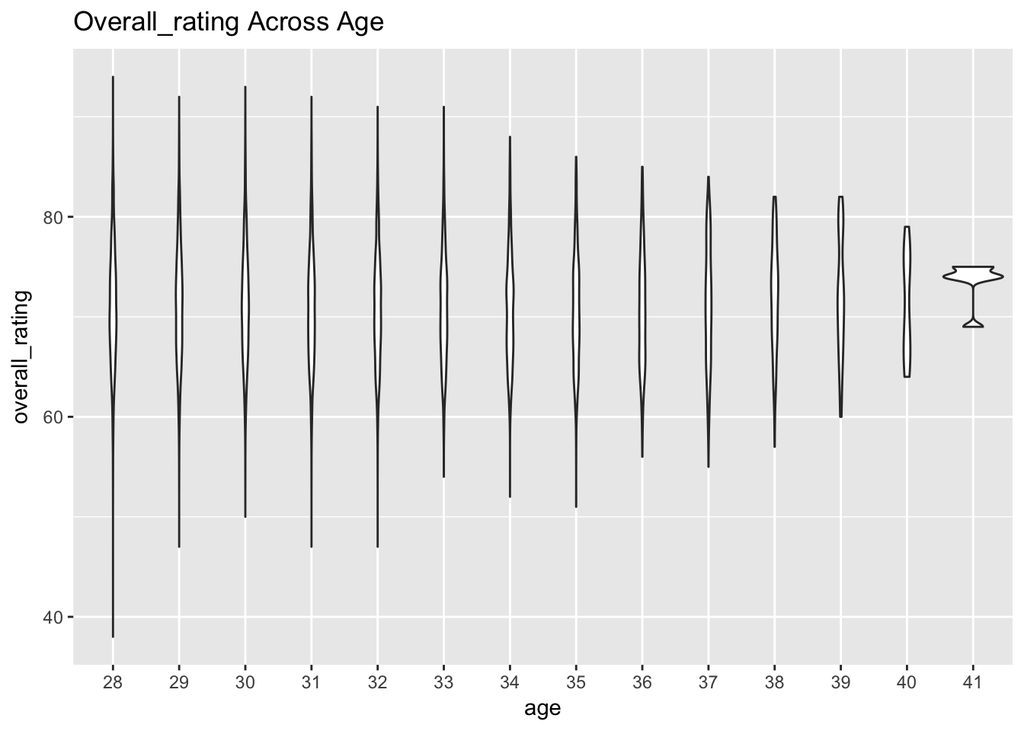

```r
players %>% filter( age >= 28) %>%
  ggplot(aes(x=factor(age), y=overall_rating)) + geom_violin() +
    labs(title="Overall_rating Across Age",
         x = "age",
         y = "overall_rating")
```

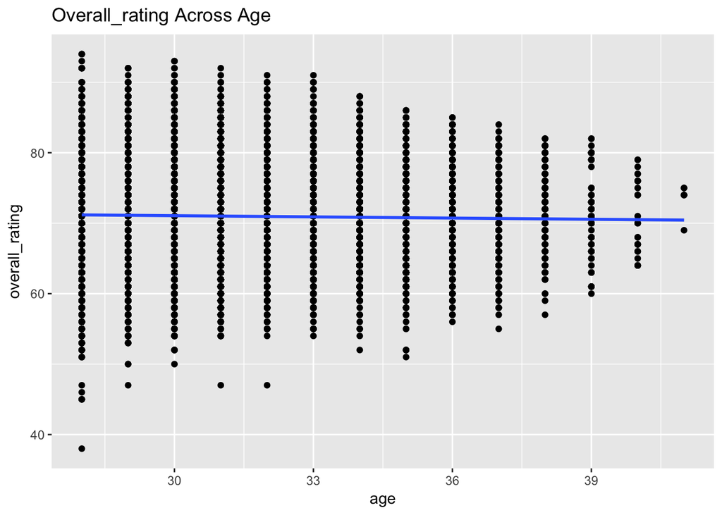

```r
players %>% filter( age >= 28) %>%
  ggplot(aes(x=age, y=overall_rating)) + geom_point() + geom_smooth(method = lm) +
    labs(title="Overall_rating Across Age",
         x = "age",
         y = "overall_rating")
```

## Part(3) Non-goal Player-model predict (Linear Model Estimate)

The purpose of this part is to estimate players’ overall_rating based on various attributes. The reason why I introduced this part is beacuse if you were a soccer manager of club, in the Transfer Martket you want to buy a player. You should use soccers’ attributes to estimate players’ performance beforing decding if you want to buy this player. Firstly, we use Linear Model to approach the estimation and then we use random forest tree method to approach.

Now we use linear model to estimate football players’ over_all ratings, After getting the STAT of linear fit. I filter those attrbutes that have less than 0.05 p.value. The reason is that they cannot reject the Null Hypothesis: There are no relations between them

Then after arranging by estimate, We find attacking_work_rate, potential,age,reactions, ball_control contributes a lot to the over_all rating. Therefore, if I were the manager, I will focus more on these 5 parts when choosing players.

```r
auto_fit <- lm(overall_rating ~ potential+preferred_foot+attacking_work_rate+
              crossing+finishing+age+vision+height+weight+curve+dribbling+volleys+short_passing+
                long_passing+free_kick_accuracy+ball_control+agility+reactions+balance+shot_power+
                jumping + heading_accuracy+balance+sprint_speed+acceleration , data = players)
auto_fit_status <- auto_fit %>% broom::tidy()
auto_fit_status %>% filter(p.value < 0.05) %>% arrange(desc(estimate))
```

```
##                         term      estimate    std.error  statistic
## 1     attacking_work_ratelow   0.740336343 0.0298950169  24.764540
## 2                  potential   0.515583957 0.0014822426 347.840469
## 3                        age   0.444616422 0.0017555506 253.263237
## 4                  reactions   0.155557419 0.0010267066 151.511074
## 5               ball_control   0.107344785 0.0014567543  73.687640
## 6           heading_accuracy   0.068629853 0.0007311134  93.870329
## 7              short_passing   0.046341837 0.0013379174  34.637293
## 8               sprint_speed   0.033673730 0.0011827995  28.469518
## 9               long_passing   0.030340088 0.0009009982  33.673862
## 10              acceleration   0.023481821 0.0012737710  18.434885
## 11                shot_power   0.017254367 0.0007028177  24.550272
## 12                   jumping   0.013063014 0.0006249142  20.903692
## 13                    height   0.012835320 0.0016892218   7.598363
## 14                    weight   0.009143792 0.0006266714  14.591048
```

[output cut: 39 more lines]

## part(4) Will Player do better than last year?

Another important task of soccer manger is that renewal a soccer player. Should I give him a higher salary? So, He should consider whether the player will do better than last year or not. If not, I may end the contract.

# (1)

```r
  players2 <- players %>% filter(year == "2012" |
                                 year == "2013" |
                                 year == "2014" |
                                 year == "2015" |
                                 year == "2016" )
  players3 <- players2 %>% group_by(year,id.x) %>% mutate(av_overall_rating = sum(overall_rating)/n()) %>% ungroup()
  ## calculate the average
  players3 <- players3 %>% distinct(id.x, year, .keep_all = TRUE) ##delete the duplicate for next step
  players4 <- players3 %>%      ## seperate them
    select(id.x,year,av_overall_rating) %>%
    tidyr::spread(year,av_overall_rating)
  players4 <- players4 %>% drop_na()      ## drop NA
  players4
```

```
## # A tibble: 3,440 x 6
##     id.x `2012` `2013` `2014` `2015` `2016`
##    <int>  <dbl>  <dbl>  <dbl>  <dbl>  <dbl>
##  1     2   66.5   69.2   70.3   72.8   73.7
##  2     3   65.0   69.8   68.0   66.0   65.0
##  3     4   69.5   67.7   67.0   68.0   69.0
##  4     6   75.0   79.0   78.5   77.2   77.0
##  5    12   62.0   65.0   65.0   69.7   74.5
##  6    14   64.5   66.4   69.5   70.6   70.0
##  7    15   78.0   78.2   81.8   82.0   82.0
##  8    18   62.0   63.0   63.8   65.5   65.0
##  9    21   75.5   74.0   74.0   74.7   74.0
## 10    23   72.0   71.3   71.0   72.0   73.0
## # ... with 3,430 more rows
```

# (2)

In this step, we need to prepare outcome_df. We use value of 2016-2015 as our outcome

```r
outcome_df <- players4 %>%
  mutate(diff = `2016` - `2015`) %>%
  mutate(Direction = ifelse(diff>0, "up", "down")) %>%
  select(id.x, Direction)
outcome_df
```

```
## # A tibble: 3,440 x 2
##     id.x Direction
##    <int> <chr>
##  1     2 up
##  2     3 down
##  3     4 up
##  4     6 down
##  5    12 up
##  6    14 down
##  7    15 down
##  8    18 down
##  9    21 down
## 10    23 up
## # ... with 3,430 more rows
```

# (3)

In this step,we need to prepare our predictor data, I will use the difference between two years as estimators. This is just like what we did in the Project(3).

```r
players5 <- players4 %>% select(-2016)
matrix_1 <- players4 %>%
  select(-id.x) %>%
  as.matrix() %>%
  .[,-1]


matrix_2 <- players4 %>%
  select(-id.x) %>%
  as.matrix() %>%
  .[,-ncol(.)]

diff_df <- (matrix_1 - matrix_2) %>%
  magrittr::set_colnames(NULL) %>%
  as_data_frame() %>%
  mutate(id.x = players4$id.x)

final_df <- diff_df %>%
  inner_join(outcome_df %>% select(id.x, Direction), by="id.x") %>%
  mutate(Direction=factor(Direction, levels=c("down", "up")))
final_df
```

```
## # A tibble: 3,440 x 6
##        V1     V2     V3     V4  id.x Direction
##     <dbl>  <dbl>  <dbl>  <dbl> <int> <fct>
##  1  2.72   1.11   2.50   0.833     2 up
##  2  4.78  -1.78  -2.00  -1.00      3 down
##  3 -1.83  -0.667  1.00   1.00      4 up
##  4  4.00  -0.500 -1.30  -0.200     6 down
##  5  3.00   0      4.70   4.80     12 up
##  6  1.90   3.10   1.12  -0.625    14 down
##  7  0.167  3.67   0.167  0        15 down
##  8  1.00   0.750  1.75  -0.500    18 down
##  9 -1.50   0      0.667 -0.667    21 down
## 10 -0.667 -0.333  1.00   1.00     23 up
## # ... with 3,430 more rows
```

## use Random Forest tree to estimate

First we need to seperate data into trainning part and test_data_part. In this case, 80% will be trainning dataset and the rest 20% will be test dataset

```r
set.seed(1234)  ##sample_frac will be random choice!!!
test_random_forest_df <- final_df %>%
  group_by(Direction) %>%
  sample_frac(.2) %>%
  ungroup()
train_random_forest_df <- final_df %>%
  anti_join(test_random_forest_df, by="id.x")
```

## implement the Random Forest tree

Prose: When I use the Randmon Forest tree to estimate, and then use trainning data and test data to test. Both error rates are 0%. This model can help soccer club manager easily,accurately, and quciky make the judgement whether a player will perform better in the next year ot not.

```r
library(randomForest)
library(tree)
rf <- randomForest(Direction~., data=train_random_forest_df %>% select(-id.x)) ## we don't want id.x as a preictor
rf
```

```
##
## Call:
##  randomForest(formula = Direction ~ ., data = train_random_forest_df %>%      select(-id.x))
##                Type of random forest: classification
##                      Number of trees: 500
## No. of variables tried at each split: 2
##
##         OOB estimate of  error rate: 0%
## Confusion matrix:
##      down   up class.error
## down 1196    0           0
## up      0 1556           0
```

```r
rf_test_predictions <- predict(rf, newdata=test_random_forest_df %>% select(-id.x),type="class")

table(pred=rf_test_predictions, observed=test_random_forest_df$Direction)
```

```
##       observed
## pred   down  up
##   down  299   0
##   up      0 389
```

## K-FOLD-CROSS-VALIDATION EXPERIMENT

And now, We use a much more stronger test to test my data. I find the error is still 0%.

```r
library(ISLR)
library(cvTools)
library(tree)
set.seed(1234) #should we use this??

fold_indices <- cvFolds(n=nrow(final_df), K=10)

error_rates <- sapply(1:10, function(fold_index){
  test_indices <- which(fold_indices$which == fold_index)
  test_set <- final_df[test_indices,] ## we use code from final_df, this kind of indices used for test

  ## use other indices for train data
  train_set <- final_df[-test_indices,]

  frf <- randomForest(Direction~., data=train_set %>% select(-id.x))
  frf_predit <- predict(frf, newdata=test_set %>% select(-id.x),type="class")
  rf_error <- mean(test_set$Direction != frf_predit)

  rf_error
  })
error_rates <- as.data.frame(t(error_rates))
error_rates <- error_rates %>%
  mutate(fold=1:n()) %>%
  gather(method,error,-fold)

error_rates %>%
  knitr::kable("html")
```

| fold | method | error |
| --- | --- | --- |
| 1 | V1 | 0 |
| 1 | V2 | 0 |
| 1 | V3 | 0 |
| 1 | V4 | 0 |
| 1 | V5 | 0 |
| 1 | V6 | 0 |
| 1 | V7 | 0 |
| 1 | V8 | 0 |
| 1 | V9 | 0 |
| 1 | V10 | 0 |